# Analysis of UN Global Compact text

22 May 2019

#Data

Loading data from the UNGC data

```r
#Loading packages and data
library(readtext)
library(quanteda)
library(dplyr)
library(tidyr)
library(stringr)
```

```r
library(ggplot2)
library(rworldmap)
library(RColorBrewer)
library(haven)
library(readxl)
DATA_DIR <- "../data/cops/"

ungc_files <- readtext(paste0(DATA_DIR, "txts/*"),
                                 docvarsfrom = "filenames",
                                 dvsep="-SEP-",
                                 docvarnames = c("Country", "Year", "Sector", "Name"))


ungc_files$doc_id <- str_replace(ungc_files$doc_id , ".txt", "") %>%
   str_replace(. , "_\\d{2}", "")
```

##Creating corpus object(s)

Sub-setting corpus by sector

```r
ungc_hces <- ungc_files %>%
  filter(Sector=="HealthCareEquipment&Ser...")
```

```r
ungc_corpus <- corpus(ungc_hces, text_field = "text")
```

# check the n for this

```r
corp_summary <- summarise(group_by(summary(ungc_corpus, n = 2664)),
                           total_speeches=n(),total_sentences=sum(Sentences),total_words=sum(Tokens))

readr::write_csv(corp_summary, "corp_summary.csv")
```

#Pre-processing

Tokenizing corpus.

```r
#Tokenization and basic pre-processing
tok <- tokens(ungc_corpus, what = "word",
              remove_punct = TRUE,
              remove_symbols = TRUE,
              remove_numbers = TRUE,
              remove_twitter = TRUE,
              remove_url = TRUE,
              remove_hyphens = FALSE,
              verbose = TRUE)
```

```
## Starting tokenization...
```

```
## ...tokenizing 1 of 1 blocks
```

```
## ...preserving hyphens
```

```
## ...removing URLs
```

```
## ...serializing tokens 106159 unique types
## ...total elapsed:  2.571 seconds.
## Finished tokenizing and cleaning 281 texts.
```

Lowercasing and removing stopwords

```r
tok <- tokens_tolower(tok)
tok.r <- tokens_select(tok, stopwords("english"), selection = "remove", padding = FALSE)
```

#Setting up agreed dictionaries

Creating compound tokens from the key terms (phrases) in our dictionaries:

```r
mylist <- list( c("malaria"), c("diarrhoea"), c("infection"), c("disease"), c("sars"), c("measles"), c("pneumonia"), c("epidemic"), c("pandemic"), c("public", "health") , c("health","care"), c("epidemiology"), c("healthcare"), c("health"), c("mortality"), c("morbidity"), c("nutrition"), c("illness"), c("infectious"), c("ncd"), c("non-communicable", "disease"), c("noncommunicable","disease"), c("communicable", "disease"), c("air", "pollution"), c("nutrition"), c("malnutrition"), c("mental", "disorder"), c("stunting"), c("climate","change"), c("global","warming"), c("green","house"), c("temperature"), c("extreme","weather"), c("global", "environmental", "change"), c("climate","variability"), c("greenhouse"), c("low","carbon"), c("ghge"), c("renewable","energy"), c("carbon","emission"), c("co2","emission"), c("climate","pollutant"))
```

```r
tok.compound <- tokens_compound(tok.r, mylist, valuetype = "fixed", concatenator = "_")
```

Creating the dictionary of climate change terms:

```r
climate_dict <- dictionary(list(climate =  c("climate_change", "global_warming", "green_house", "temperature", "extreme_weather", "global_environmental_change", "climate_variability", "greenhouse", "low_carbon", "ghge", "renewable_energy", "carbon_emission", "co2_emission", "climate_pollutant")))
```

Creating the dictionary of health terms:

```r
health_dict <- dictionary(list(health = c("malaria", "diarrhoea", "infection", "disease", "sars", "measles", "pneumonia", "epidemic", "pandemic", "public_health", "health_care", "epidemiology", "healthcare", "health", "mortality", "morbidity", "nutrition", "illness", "infectious", "ncd", "non-communicable_disease", "noncommunicable_disease", "communicable_disease", "air_pollution", "nutrition", "malnutrition", "mental_disorder", "stunting")))
```

## KWIC

We search for terms from our health dictionary and show the 25-word context around them.

```r
tok.hea <- kwic(tok.compound, health_dict, window = 25, valuetype = "fixed")

readr::write_csv(tok.hea, "health_kwic_25_fixed.csv")
```

We search for terms from our climate change dictionary and show the 25-word context around them.

```r
tok.cc <- kwic(tok.compound, climate_dict, window = 25, valuetype = "fixed")

readr::write_csv(tok.cc, "climate_kwic_25_fixed.csv")
```

To tap into the core proposition of this analysis - the link between climate change and health terms - we take the 25-word context around the health terms and search this context for climate change terms.

Text surrounding health terms (25 words each side) is saved and transformed to a corpus object. We then perform key-word-in-context search of this health related corpus for the terms in our climate change dictionary.

```r
corpus_health <- corpus(tok.hea, split_context = FALSE, extract_keyword = TRUE)

tok.climate.kwic <- kwic(corpus_health, climate_dict, window = 25, valuetype = "fixed")

readr::write_csv(tok.climate.kwic, "intersection_kwic_25_fixed.csv")
```

### Robustness analysis

For robustness analysis we looked at different context window sizes and manually assessed them for the balance of false positives vs false negatives.

```r
tok.hea.5 <- kwic(tok.compound, health_dict, window = 5, valuetype = "fixed")
tok.cc.5 <- kwic(tok.compound, climate_dict, window = 5, valuetype = "fixed")
corpus_health.5 <- corpus(tok.hea.5, split_context = FALSE, extract_keyword = TRUE)
tok.climate.kwic.5 <- kwic(corpus_health.5, climate_dict, window = 5, valuetype = "fixed")
readr::write_csv(tok.climate.kwic.5, "intersection_kwic_5_fixed.csv")
readr::write_csv(tok.hea.5, "health_kwic_5_fixed.csv")
readr::write_csv(tok.cc.5, "climate_kwic_5_fixed.csv")

tok.hea.10 <- kwic(tok.compound, health_dict, window = 10, valuetype = "fixed")
tok.cc.10 <- kwic(tok.compound, climate_dict, window = 10, valuetype = "fixed")
corpus_health.10 <- corpus(tok.hea.10, split_context = FALSE, extract_keyword = TRUE)
tok.climate.kwic.10 <- kwic(corpus_health.10, climate_dict, window = 10, valuetype = "fixed")
readr::write_csv(tok.climate.kwic.10, "intersection_kwic_10_fixed.csv")
readr::write_csv(tok.hea.10, "health_kwic_10_fixed.csv")
readr::write_csv(tok.cc.10, "climate_kwic_10_fixed.csv")

tok.hea.30 <- kwic(tok.compound, health_dict, window = 30, valuetype = "fixed")
tok.cc.30 <- kwic(tok.compound, climate_dict, window = 30, valuetype = "fixed")
corpus_health.30 <- corpus(tok.hea.30, split_context = FALSE, extract_keyword = TRUE)
tok.climate.kwic.30 <- kwic(corpus_health.30, climate_dict, window = 30, valuetype = "fixed")
readr::write_csv(tok.climate.kwic.30, "intersection_kwic_30_fixed.csv")
readr::write_csv(tok.hea.30, "health_kwic_30_fixed.csv")
readr::write_csv(tok.cc.30, "climate_kwic_30_fixed.csv")

tok.hea.50 <- kwic(tok.compound, health_dict, window = 50, valuetype = "fixed")
tok.cc.50 <- kwic(tok.compound, climate_dict, window = 50, valuetype = "fixed")
corpus_health.50 <- corpus(tok.hea.50, split_context = FALSE, extract_keyword = TRUE)
tok.climate.kwic.50 <- kwic(corpus_health.50, climate_dict, window = 50, valuetype = "fixed")
readr::write_csv(tok.climate.kwic.50, "intersection_kwic_50_fixed.csv")
readr::write_csv(tok.hea.50, "health_kwic_50_fixed.csv")
readr::write_csv(tok.cc.50, "climate_kwic_50_fixed.csv")
```

```r
health_dfm <- dfm(corpus_health)

corpus_climate <- corpus(tok.cc, split_context = FALSE, extract_keyword = TRUE)
climate_dfm <- dfm(corpus_climate)

corpus_intersection <- corpus(tok.climate.kwic, split_context = FALSE, extract_keyword = TRUE)
intersection_dfm <- dfm(corpus_intersection)

health <- convert(health_dfm, "data.frame")
climate <- convert(climate_dfm, "data.frame")
intersection <- convert(intersection_dfm, "data.frame")

names(health)[1] <- "docid"
names(climate)[1] <- "docid"
names(intersection)[1] <- "docid"

health$"docid" <- str_match(health$docid, "(.*)(\\.L\\d)")[,2]
climate$"docid" <- str_match(climate$docid, "(.*)(\\.L\\d)")[,2]
intersection$"docid" <- str_match(intersection$docid, "(.*)(\\.L\\d)")[,2]

health_counts <- health %>% group_by(docid) %>% summarise(health_count = n())
climate_counts <- climate %>% group_by(docid) %>% summarise(climate_count = n())
intersection_counts <- intersection %>% group_by(docid) %>% summarise(intersection_count = n())

total_counts <- climate_counts %>%
  full_join(health_counts, by = "docid") %>%
  full_join(intersection_counts, by = "docid") %>%
  replace_na(list(health_count=0, climate_count=0, intersection_count=0)) %>%
  separate(docid, c("country", "year", "sector", "name"), "-SEP-")

total_counts$year <- as.numeric(total_counts$year)

total_counts <- arrange(total_counts, country, year, sector, name)
```

```r
readr::write_csv(total_counts, "total_counts.csv")
```

Defining WHO regions

```r
africa = as.data.frame(c("Algeria", "Angola", "Benin", "Botswana", "British Indian Ocean Territory",
                         "Burkina Faso", "Burundi", "Cabo Verde", "Cameroon", "Central African Republic",
                         "Chad", "Comoros", "Congo, Democratic Republic of the", "Cote d'Ivoire",
                         "Democratic Republic of the Congo", "Congo, Republic of the",
                         "Equatorial Guinea", "Eritrea", "Ethiopia", "French Southern Territories", "Gabon",
                         "Gambia", "Ghana", "Guinea", "Guinea-Bissau", "Kenya", "Lesotho", "Liberia",
                         "Madagascar", "Malawi", "Mali", "Mauritania", "Mauritius", "Mayotte", "Mozambique",
                         "Namibia", "Niger", "Nigeria", "Rwanda", "Réunion", "Saint Helena",
                         "Sao Tome And Principe", "Senegal", "Seychelles", "Sierra Leone", "South Africa",
                         "South Sudan", "Swaziland", "Togo", "Uganda", "Tanzania, United Republic of",
                         "Western Sahara", "Zambia", "Zimbabwe"))
names(africa)[1] <- "countries"
africa$who_region <- "africa"

eastern_mediterranean = as.data.frame(c("Afghanistan", "Bahrain", "Djibouti", "Egypt",
                                        "Iran, Islamic Republic of", "Iraq", "Jordan", "Kuwait", "Lebanon",
                                        "Libya", "Morocco", "Oman", "Pakistan", "Qatar", "Saudi Arabia",
                                        "Somalia", "Palestine, State of", "Sudan", "Syrian Arab Republic",
                                        "Tunisia", "United Arab Emirates", "Yemen"))
names(eastern_mediterranean)[1] <- "countries"
eastern_mediterranean$who_region <- "eastern_mediterranean"

europe = as.data.frame(c("Albania", "Andorra", "Armenia", "Austria", "Azerbaijan", "Belarus", "Belgium",
                         "Bosnia-Herzegovina", "Bulgaria", "Croatia", "Cyprus", "Czechia", "Denmark",
                         "Estonia", "Faroe Islands", "Finland", "France", "Georgia", "Germany", "Gibraltar",
                         "Greece", "Guernsey", "Holy See", "Hungary", "Iceland", "Ireland", "Isle of Man",
                         "Israel", "Italy", "Jersey", "Kazakhstan", "Kyrgyzstan", "Latvia", "Liechtenstein",
                         "Lithuania", "Luxembourg", "Malta", "Monaco", "Montenegro", "Netherlands", "North Macedonia", "Norway",
                         "Poland", "Portugal", "Moldova, Republic of", "Romania", "Russian Federation",
                         "San Marino", "Sark", "Serbia", "Slovakia", "Slovenia", "Spain",
                         "Svalbard and Jan Mayen Islands", "Sweden", "Switzerland", "Tajikistan",
                         "Macedonia, The former Yugoslav Republic of", "Turkey", "Turkmenistan", "Ukraine",
                         "United Kingdom", "Uzbekistan",
                         "Åland Islands"))
names(europe)[1] <- "countries"
europe$who_region <- "europe"

latin_america_and_the_caribbean = as.data.frame(c("Anguilla", "Antigua and Barbuda", "Argentina", "Aruba",
                                                  "Bahamas", "Barbados", "Belize", "Bolivia", "Bonaire",
                                                  "Bouvet Island", "Brazil", "British Virgin Islands",
                                                  "Cayman Islands", "Chile", "Colombia", "Costa Rica", "Cuba",
                                                  "Curaçao", "Dominica", "Dominican Republic", "Ecuador",
                                                  "El Salvador", "Falkland Islands (Malvinas)", "French Guiana",
                                                  "Grenada", "Guadeloupe", "Guatemala", "Guyana", "Haiti",
                                                  "Honduras", "Jamaica", "Martinique", "Mexico", "Montserrat",
                                                  "Nicaragua", "Panama", "Paraguay", "Peru", "Puerto Rico",
                                                  "Saint Barthթlemy", "Saint Kitts and Nevis", "Saint Lucia",
                                                  "Saint Martin", "Saint Vincent and the Grenadines",
                                                  "Sint Maarten", "South Georgia and the South Sandwich Islands",
                                                  "Suriname", "Trinidad And Tobago", "Turks and Caicos Islands",
                                                  "Virgin Islands", "Uruguay", "Venezuela"))
names(latin_america_and_the_caribbean)[1] <- "countries"
latin_america_and_the_caribbean$who_region <- "latin_america_and_the_caribbean"

north_america = as.data.frame(c("Bermuda", "Canada", "Greenland", "Saint Pierre and Miquelon",
                                "United States of America"))
names(north_america)[1] <- "countries"
north_america$who_region <- "north_america"

south_east_asia = as.data.frame(c("Bangladesh", "Bhutan", "Democratic People's Republic of Korea", "India",
                                  "Indonesia", "Maldives", "Myanmar", "Nepal", "Sri Lanka", "Thailand",
                                  "Timor-Leste"))
names(south_east_asia)[1] <- "countries"
south_east_asia$who_region <- "south_east_asia"

western_pacific = as.data.frame(c("American Samoa", "Australia", "Brunei", "Cambodia", "China",
                                  "Hong Kong", "Macao", "Taiwan", "Christmas Island", "Cocos (Keeling) Islands",
                                  "Cook Islands", "Fiji", "French Polynesia", "Guam",
                                  "Heard Island and McDonald Islands", "Japan", "Kiribati",
                                  "Laos", "Malaysia", "Marshall Islands", "Micronesia", "Mongolia", "Nauru",
                                  "New Caledonia", "New Zealand", "Niue", "Norfolk Island",
                                  "Northern Mariana Islands", "Palau", "Papua New Guinea", "Philippines",
                                  "Pitcairn", "Korea, Republic of", "Samoa", "Singapore", "Solomon Islands",
                                  "Tokelau", "Tonga", "Tuvalu", "Minor Outlying Islands", "Vanuatu",
                                  "Viet Nam", "Wallis and Futuna Islands"))
names(western_pacific)[1] <- "countries"
western_pacific$who_region <- "western_pacific"

countries_who_regions <- do.call("rbind", list(africa, eastern_mediterranean, europe, latin_america_and_the_caribbean, north_america, south_east_asia, western_pacific))
```

Defining SIDS, Tier 1, Tier 2 regions

```r
sids_countries = as.data.frame(c("American Samoa", "Anguilla", "Antigua and Barbuda", "Bahamas", "Bahrain", "Barbados", "Belize", "Bermuda", "Cape Verde", "Comoros", "Cook Islands", "Cuba", "Dominica", "Fiji", "Grenada", "Guam", "Guinea-Bissau", "Guyana", "Haiti", "Jamaica", "Kiribati", "Maldives", "Marshall Islands", "Mauritius", "Micronesia", "Montserrat", "Nauru", "New Caledonia", "Niue", "Palau", "Papua New Guinea", "Puerto Rico", "Saint Kitts and Nevis", "Saint Lucia", "Saint Vincent and the Grenadines", "Samoa", "Sao Tome and Principe", "Seychelles", "Singapore", "Solomon Islands", "Suriname", "Timor-Leste", "Tonga", "Trinidad and Tobago", "Tuvalu", "Vanuatu"))
names(sids_countries)[1] <- "countries"
sids_countries$region <- "sids"

tier1_countries = as.data.frame(c("United States of America", "China"))
names(tier1_countries)[1] <- "countries"
tier1_countries$region <- "tier1"

tier2_countries = as.data.frame(c("Poland", "Australia", "South Africa", "Brazil", "India", "France", "Germany", "Indonesia", "United Kingdom"))
names(tier2_countries)[1] <- "countries"
tier2_countries$region <- "tier2"
```

Processing country names

```r
`%not_in%` <- purrr::negate(`%in%`)

abbrev_countries <- str_extract(total_counts$country, '(?<=^)[^\\.]+')
total_counts$country[abbrev_countries %not_in% countries_who_regions]

total_counts$country[total_counts$country == "Korea, Repub..."] <- "Korea, Republic of"
total_counts$country[total_counts$country == "United State..."] <- "United States of America"
total_counts$country[total_counts$country == "Syrian Arab ..."] <- "Syrian Arab Republic"

ungc_hces$Country[ungc_hces$Country == "Korea, Repub..."] <- "Korea, Republic of"
ungc_hces$Country[ungc_hces$Country == "United State..."] <- "United States of America"
ungc_hces$Country[ungc_hces$Country == "Syrian Arab ..."] <- "Syrian Arab Republic"
ungc_hces$Country[ungc_hces$Country == "Tanzania, Un..."] <- "Tanzania, United Republic of"
```

# Maps of mention counts

## Map for 2018 of PH and CC in HCES

```r
map <- joinCountryData2Map(subset(total_counts, year==2018 & health_count>0), joinCode="NAME", nameJoinColumn="country")
```

```
## 31 codes from your data successfully matched countries in the map
## 0 codes from your data failed to match with a country code in the map
## 224 codes from the map weren't represented in your data
```

```r
new_world <- subset(map, continent != "Antarctica")

pdf("worldmap_2018_health.pdf", width = 7, height = 3)

par(mai=c(0,0,0.2,0),xaxs="i",yaxs="i")

mapParams <- mapCountryData(new_world, nameColumnToPlot="health_count",
                            mapTitle="2018 UN Global Compact: Health",
                            catMethod = "categorical",
                            colourPalette = "heat",
                            oceanCol = "lightblue",
                            missingCountryCol = "white",
                            addLegend="FALSE")

do.call(addMapLegendBoxes, c(mapParams,title="Number of mentions",x = "bottom", horiz=TRUE, cex=0.5))

dev.off()
```

```r
map <- joinCountryData2Map(subset(total_counts, year==2018 & climate_count>0), joinCode="NAME", nameJoinColumn="country")
```

```
## 20 codes from your data successfully matched countries in the map
## 0 codes from your data failed to match with a country code in the map
## 229 codes from the map weren't represented in your data
```

```r
new_world <- subset(map, continent != "Antarctica")

pdf("worldmap_2018_climate.pdf", width = 7, height = 3)

par(mai=c(0,0,0.2,0),xaxs="i",yaxs="i")

mapParams <- mapCountryData(new_world, nameColumnToPlot="climate_count",
                            mapTitle="2018 UN Global Compact: Climate Change",
                            catMethod = "categorical",
                            colourPalette = "heat",
                            oceanCol = "lightblue",
                            missingCountryCol = "white",
                            addLegend="FALSE")

do.call( addMapLegendBoxes, c(mapParams,title="Number of mentions",x = "bottom", horiz=TRUE, cex=0.5))

dev.off()
```

```r
map <- joinCountryData2Map(subset(total_counts, year==2018 & intersection_count>0), joinCode="NAME", nameJoinColumn="country")
```

[output not shown]

```r
new_world <- subset(map, continent != "Antarctica")

pdf("worldmap_2018_intersection.pdf", width = 7, height = 3)

par(mai=c(0,0,0.2,0),xaxs="i",yaxs="i")

mapParams <- mapCountryData(new_world, nameColumnToPlot="intersection_count",
                            mapTitle="2018 UN Global Compact: Intersection",
                            catMethod = "categorical",
                            colourPalette = "heat",
                            oceanCol = "lightblue",
                            missingCountryCol = "white",
                            addLegend="FALSE")

do.call( addMapLegendBoxes, c(mapParams,title="Number of mentions",x = "bottom", horiz=TRUE, cex=0.5))

dev.off()
```

# Time series of total counts plot

## total counts

```r
# calculating the total number of mentions by year
sum_total <- summarise(group_by(total_counts, year),
                 sum_CC = sum(climate_count), sum_PH = sum(health_count), sum_int = sum(intersection_count),
                 mean_CC = mean(climate_count), mean_PH = mean(health_count), mean_int = mean(intersection_count))
```

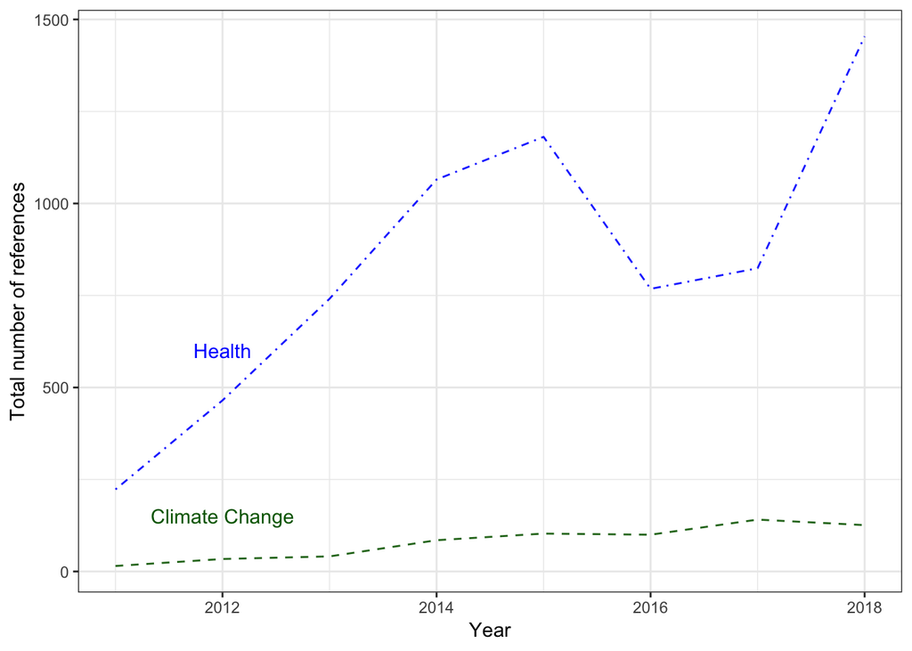

```r
ggplot(sum_total, aes(x=year)) +
  theme_bw() +
  geom_line(aes(y= sum_PH), colour = "blue", alpha = 0.9, linetype="dotdash") +
  geom_line(aes(y= sum_CC), colour = "darkgreen", alpha = 0.9, linetype="dashed") +
#  geom_line(aes(y= count), colour = "black", alpha = 0.9) +
  #ggtitle("Political engagement with the intersection of climate change and health") +
  ylab("Total number of references") + xlab("Year") +
#  scale_y_continuous(limits=c(0, 140), breaks = c(1, 50, 100, 134)) +
  scale_x_continuous(limits=c(2011, 2018), breaks = c(2012,2014,2016,2018))+
 annotate("text", x = 2012, y = 150, label = "Climate Change", colour = "darkgreen")+
  annotate("text", x = 2012, y = 600, label = "Health", colour = "blue")
```

```r
ggsave("timeseries_PHCC_total_count.pdf")
```

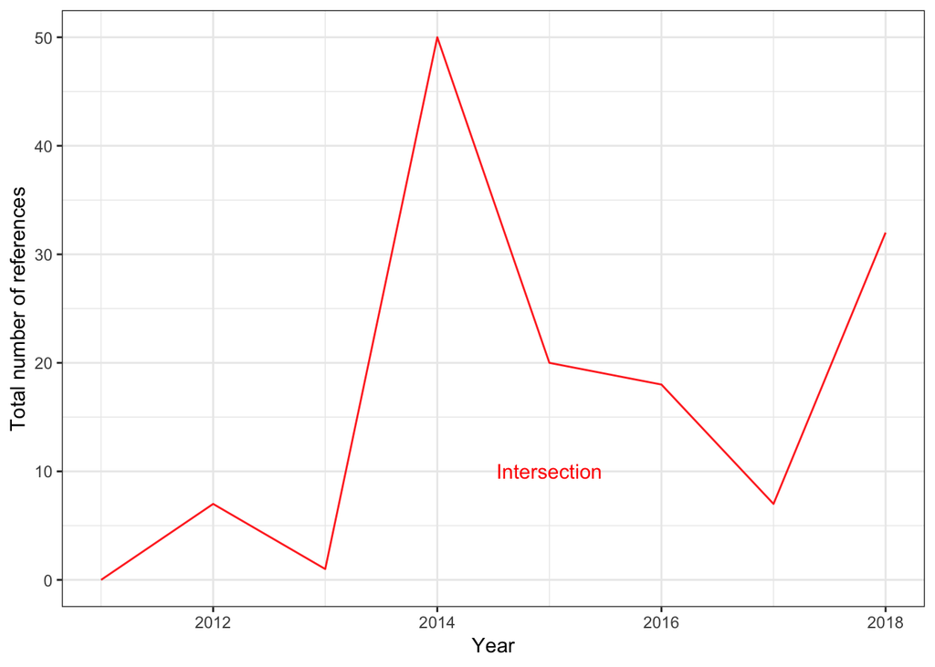

```r
ggplot(sum_total, aes(x=year)) +
  theme_bw() +
  geom_line(aes(y= sum_int), colour = "red", alpha = 0.9) +
  ylab("Total number of references") + xlab("Year") +
#  scale_y_continuous(limits=c(0, 140), breaks = c(1, 50, 100, 134)) +
  scale_x_continuous(limits=c(2011, 2018), breaks = c(2012,2014,2016,2018))+
   annotate("text", x = 2015, y = 10, label = "Intersection", colour = "red")
```

```r
ggsave("timeseries_intersection_total_count.pdf")
```

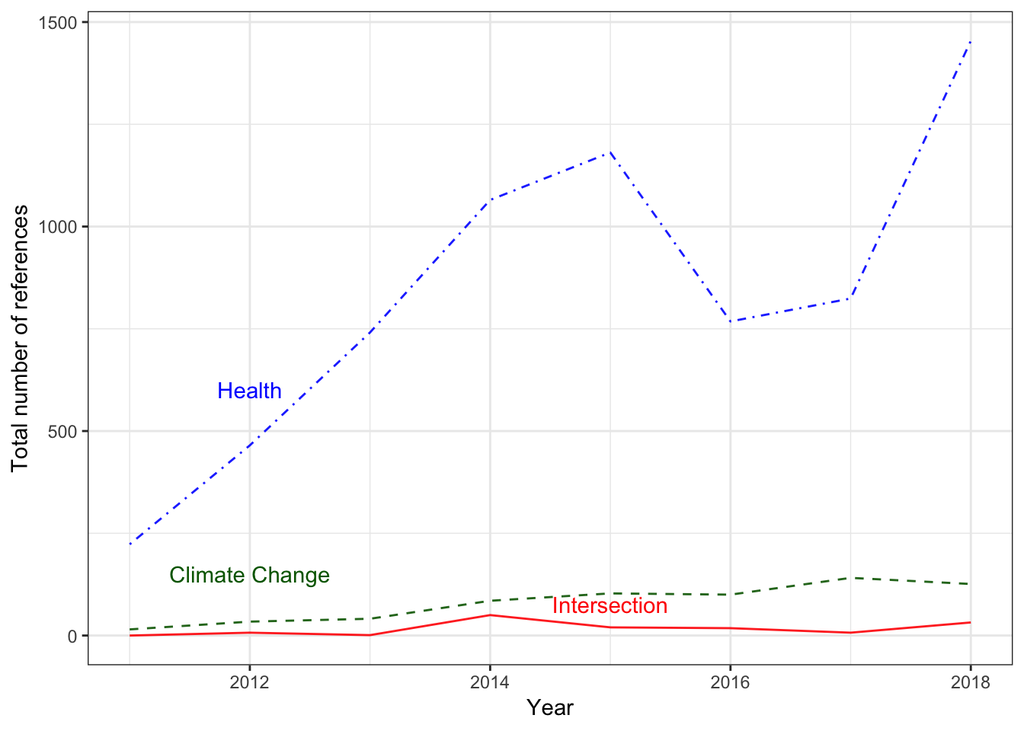

```r
ggplot(sum_total, aes(x=year)) +
  theme_bw() +
  geom_line(aes(y= sum_PH), colour = "blue", alpha = 0.9, linetype="dotdash") +
  geom_line(aes(y= sum_CC), colour = "darkgreen", alpha = 0.9, linetype="dashed") +
  geom_line(aes(y= sum_int), colour = "red", alpha = 0.9) +
  #ggtitle("Political engagement with the intersection of climate change and health") +
  ylab("Total number of references") + xlab("Year") +
#  scale_y_continuous(limits=c(0, 140), breaks = c(1, 50, 100, 134)) +
  scale_x_continuous(limits=c(2011, 2018), breaks = c(2012,2014,2016,2018))+
 annotate("text", x = 2012, y = 150, label = "Climate Change", colour = "darkgreen")+
  annotate("text", x = 2012, y = 600, label = "Health", colour = "blue") +
  annotate("text", x = 2015, y = 75, label = "Intersection", colour = "red")
```

```r
ggsave("timeseries_all_total_count.pdf")
```

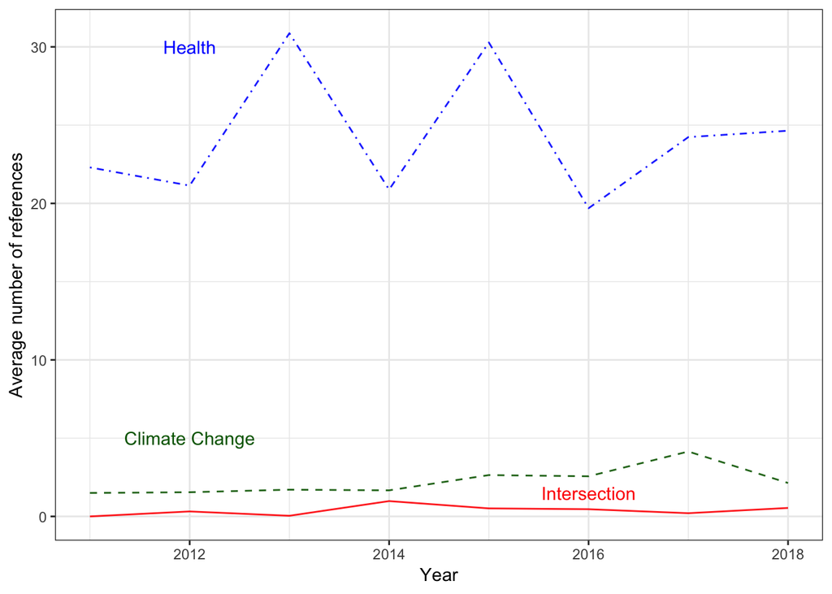

```r
ggplot(sum_total, aes(x=year)) +
  theme_bw() +
  geom_line(aes(y= mean_PH), colour = "blue", alpha = 0.9, linetype="dotdash") +
  geom_line(aes(y= mean_CC), colour = "darkgreen", alpha = 0.9, linetype="dashed") +
  geom_line(aes(y= mean_int), colour = "red", alpha = 0.9) +
  #ggtitle("Political engagement with the intersection of climate change and health") +
  ylab("Average number of references") + xlab("Year") +
#  scale_y_continuous(limits=c(0, 140), breaks = c(1, 50, 100, 134)) +
  scale_x_continuous(limits=c(2011, 2018), breaks = c(2012,2014,2016,2018))+
 annotate("text", x = 2012, y = 5, label = "Climate Change", colour = "darkgreen")+
  annotate("text", x = 2012, y = 30, label = "Health", colour = "blue") +
  annotate("text", x = 2016, y = 1.5, label = "Intersection", colour = "red")
```

```r
ggsave("timeseries_all_avg_count.pdf")
```

## Proportion of countries presentation

Proportion of countries that had at least one mention

Data preparation

```r
climate_texts <- total_counts %>% filter(climate_count>0) %>% group_by(year) %>% tally(name = "climate_texts")
health_texts <- total_counts %>% filter(health_count>0) %>% group_by(year) %>% tally(name = "health_texts")
intersection_texts <- total_counts %>% filter(intersection_count>0) %>% group_by(year) %>% tally(name = "intersection_texts")
total_texts <- ungc_hces %>% group_by(Year) %>% tally(name = "total_texts")

proportions <- left_join(total_texts, health_texts, by = c("Year"="year")) %>%
  left_join(., climate_texts, by = c("Year"="year")) %>%
  left_join(., intersection_texts, by = c("Year"="year")) %>%
  replace_na(list(health_texts=0, climate_texts=0, intersection_texts=0))

proportions$percent_int <- proportions$intersection_texts/proportions$total_texts*100
proportions$percent_CC <- proportions$climate_texts/proportions$total_texts*100
proportions$percent_PH <- proportions$health_texts/proportions$total_texts*100

readr::write_csv(proportions, "proportion_results.csv")
```

Plotting the country proportion

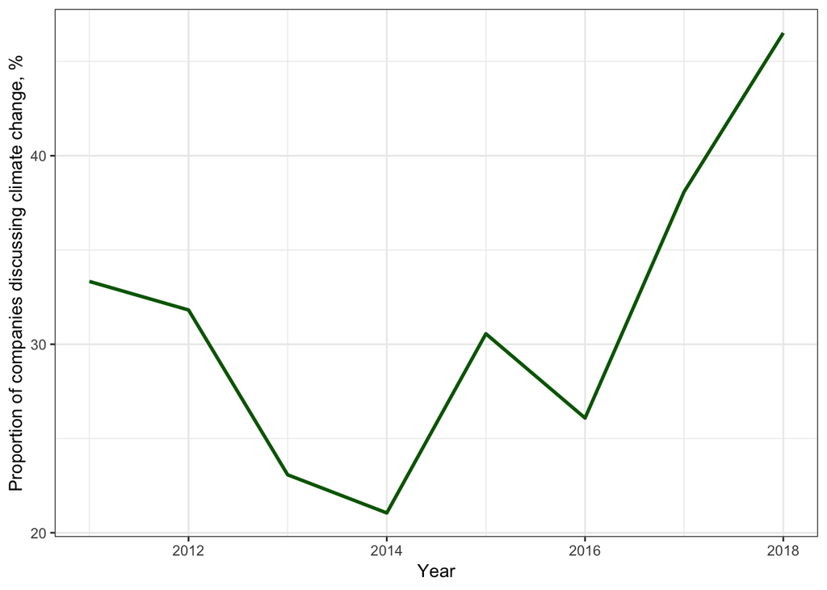

```r
ggplot(proportions, aes(x=Year, y=percent_CC, group = 1)) +
  geom_line(colour="darkgreen", size=1) +
  theme_bw() +
  #ggtitle("Corporate engagement with the intersection of climate change and health") +
  ylab("Proportion of companies discussing climate change, %") + xlab("Year") +
  scale_x_continuous(limits=c(2011, 2018), breaks = c(2012,2014,2016,2018))
```

```r
 ggsave("total_percent_CC.pdf")
```

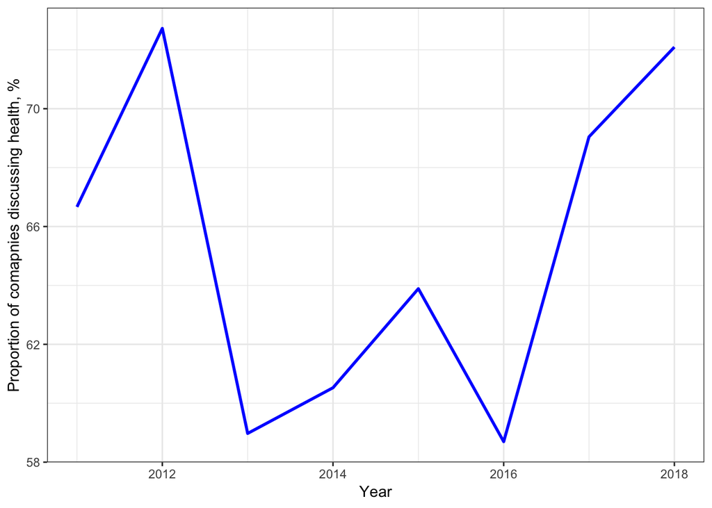

```r
ggplot(proportions, aes(x=Year, y=percent_PH, group = 1)) +
  geom_line(colour="blue", size=1) +
  theme_bw() +
  #ggtitle("Political engagement with the intersection of climate change and health") +
  ylab("Proportion of comapnies discussing health, %") + xlab("Year") +
  scale_x_continuous(limits=c(2011, 2018), breaks = c(2012,2014,2016,2018))
```

```r
  ggsave("total_percent_PH.pdf")
```

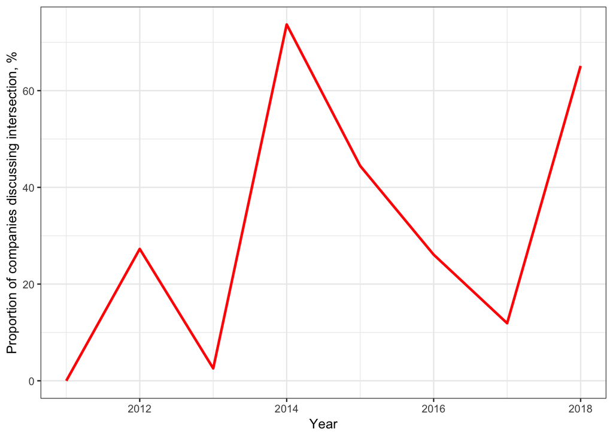

```r
ggplot(proportions, aes(x=Year, y=percent_int, group = 1)) +
  geom_line(colour="red", size=1) +
  theme_bw() +
  #ggtitle("Political engagement with the intersection of climate change and health") +
  ylab("Proportion of companies discussing intersection, %") + xlab("Year") +
  scale_x_continuous(limits=c(2011, 2018), breaks = c(2012,2014,2016,2018))
```

```r
  ggsave("total_percent_intersection.pdf")
```

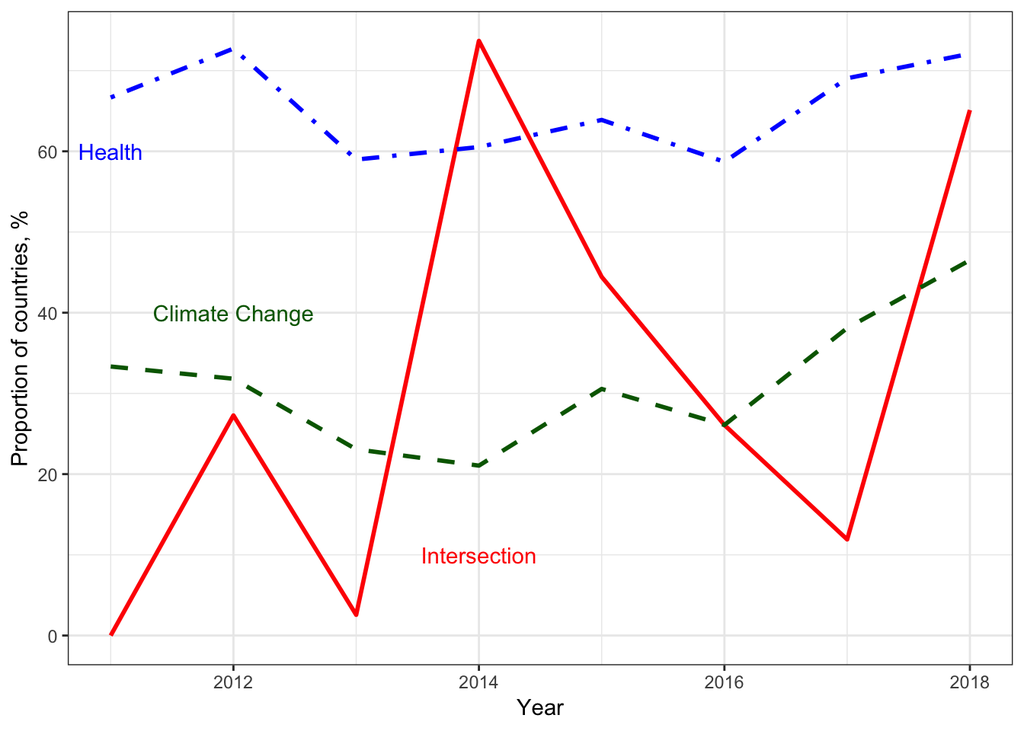

```r
ggplot(proportions, aes(x=Year)) +
  geom_line(aes(y=percent_int), colour="red", size=1) +
  geom_line(aes(y=percent_CC), colour="darkgreen", linetype = "dashed", size=1) +
  geom_line(aes(y=percent_PH), colour="blue", linetype = "dotdash", size=1) +
  theme_bw() +
  #ggtitle("Political engagement with the intersection of climate change and health") +
  ylab("Proportion of countries, %") + xlab("Year") +
  scale_x_continuous(limits=c(2011, 2018), breaks = c(2012,2014,2016,2018))+
 annotate("text", x = 2014, y = 10, label = "Intersection", colour = "red")+
  annotate("text", x = 2011, y = 60, label = "Health", colour = "blue") +
  annotate("text", x = 2012, y = 40, label = "Climate Change", colour = "darkgreen")
```

```r
  ggsave("all_three_percent.pdf")
```

#Tier Analysis Regional distribution of reports - SIDS, Tier 1, Tier 2

```r
total_counts$country_groups <- ifelse(total_counts$country %in% sids_countries$countries, "SIDS", "other")
total_counts$country_groups[total_counts$country %in% tier1_countries$countries] <- "Tier1"
total_counts$country_groups[total_counts$country %in% tier2_countries$countries] <- "Tier2"

ungc_hces$country_groups <- ifelse(ungc_hces$Country %in% sids_countries$countries, "SIDS", "none")
ungc_hces$country_groups[ungc_hces$Country %in% tier1_countries$countries] <- "Tier1"
ungc_hces$country_groups[ungc_hces$Country %in% tier2_countries$countries] <- "Tier2"
```

```r
# Data preparation
hces_tiers <- ungc_hces %>%
  group_by(country_groups, Year) %>%
  summarise(total_speeches=n())

hces_tiers <- hces_tiers %>% filter(country_groups!="none")

hces_tiers1_total <- ungc_hces %>%
  #filter(country_groups!="none") %>%
  group_by(Year) %>%
  summarise(total_speeches=n())

hces_tiers1 <- ungc_hces %>%
  select(country_groups, Year) %>%
  filter(country_groups!="none") %>%
  group_by(Year) %>%
  summarise(total_speeches=n())

hces_tiers1_sids <- ungc_hces %>%
  select(country_groups, Year) %>%
  filter(country_groups == "SIDS") %>%
  group_by(Year) %>%
  summarise(total_speeches_sids=n())

hces_tiers1_tier1 <- ungc_hces %>%
  select(country_groups, Year) %>%
  filter(country_groups == "Tier1") %>%
  group_by(Year) %>%
  summarise(total_speeches_tier1=n())

hces_tiers1_tier2 <- ungc_hces %>%
  select(country_groups, Year) %>%
  filter(country_groups == "Tier2") %>%
  group_by(Year) %>%
  summarise(total_speeches_tier2=n())

proportions_hces <- left_join(hces_tiers1_total, hces_tiers1_tier2, by = c("Year"="Year")) %>%
  left_join(., hces_tiers1_tier1, by = c("Year"="Year")) %>%
  left_join(., hces_tiers1_sids, by = c("Year"="Year")) %>%
  replace_na(list(total_speeches_sids=0, total_speeches_tier1=0, total_speeches_tier2=0))

proportions_hces$percent_sids <- proportions_hces$total_speeches_sids/proportions_hces$total_speeches*100
proportions_hces$percent_tier1 <- proportions_hces$total_speeches_tier1/proportions_hces$total_speeches*100
proportions_hces$percent_tier2<- proportions_hces$total_speeches_tier2/proportions_hces$total_speeches*100
```

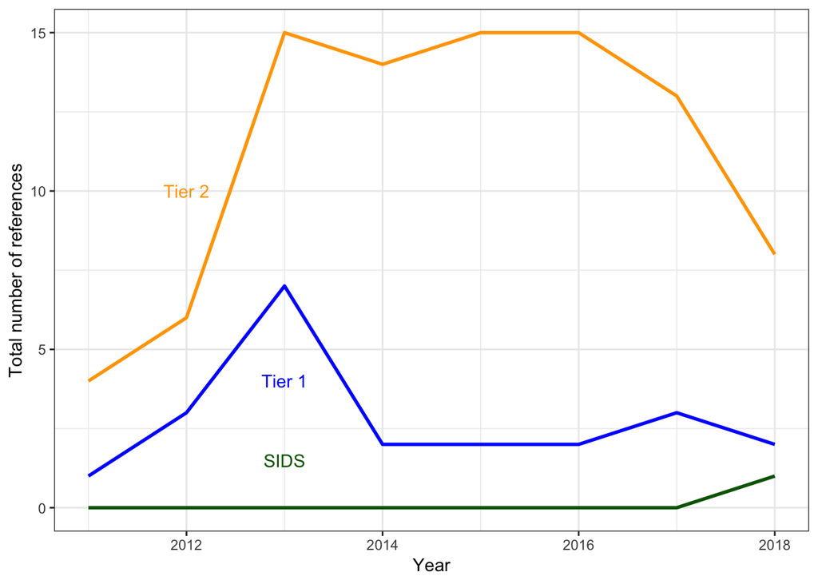

```r
ggplot(proportions_hces, aes(x=Year)) +
  geom_line(aes(y=total_speeches_sids), colour="darkgreen", size=1) +
  geom_line(aes(y=total_speeches_tier1), colour="blue", size=1) +
  geom_line(aes(y=total_speeches_tier2), colour="orange", size=1) +
  theme_bw() +
  ylab("Total number of references") + xlab("Year") +
  scale_x_continuous(limits=c(2011, 2018), breaks = c(2012,2014,2016,2018)) +
  annotate("text", x = 2012, y = 10, label = "Tier 2", colour = "orange")+
  annotate("text", x = 2013, y = 4, label = "Tier 1", colour = "blue")+
  annotate("text", x = 2013, y = 1.5, label = "SIDS", colour = "darkgreen")
```

Proportion

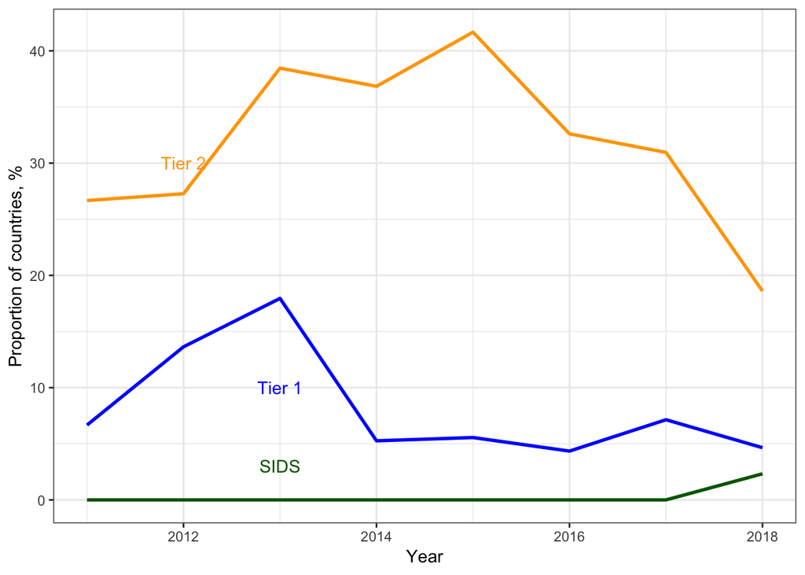

```r
ggplot(proportions_hces, aes(x=Year)) +
  geom_line(aes(y=percent_sids), colour="darkgreen", size=1) +
  geom_line(aes(y=percent_tier1), colour="blue", size=1) +
  geom_line(aes(y=percent_tier2), colour="orange", size=1) +
  theme_bw() +
  ylab("Proportion of countries, %") + xlab("Year") +
  scale_x_continuous(limits=c(2011, 2018), breaks = c(2012,2014,2016,2018)) +
  annotate("text", x = 2012, y = 30, label = "Tier 2", colour = "orange") +
  annotate("text", x = 2013, y = 10, label = "Tier 1", colour = "blue") +
  annotate("text", x = 2013, y = 3, label = "SIDS", colour = "darkgreen")
```

#WHO Countries

```r
ungc_hces$who <- ifelse(ungc_hces$Country %in% africa$countries, "Africa", "none")
ungc_hces$who[ungc_hces$Country %in% eastern_mediterranean$countries] <- "Eastern Mediterranean"
ungc_hces$who[ungc_hces$Country %in% europe$countries] <- "Europe"
ungc_hces$who[ungc_hces$Country %in% latin_america_and_the_caribbean$countries] <- "Latin American and the Carribean"
ungc_hces$who[ungc_hces$Country %in% north_america$countries] <- "North America"
ungc_hces$who[ungc_hces$Country %in% south_east_asia$countries] <- "South-East Asia"
ungc_hces$who[ungc_hces$Country %in% western_pacific$countries] <- "Western Pacific"
```

```r
hces_who_total <- ungc_hces %>%
  group_by(Year) %>%
  summarise(total_speeches=n())

hces_who_africa <- ungc_hces %>%
  select(who, Year) %>%
  filter(who == "Africa") %>%
  group_by(Year) %>%
  summarise(total_speeches_africa=n())

hces_who_em <- ungc_hces %>%
  select(who, Year) %>%
  filter(who == "Eastern Mediterranean") %>%
  group_by(Year) %>%
  summarise(total_speeches_em=n())

hces_who_europe <- ungc_hces %>%
  select(who, Year) %>%
  filter(who == "Europe") %>%
  group_by(Year) %>%
  summarise(total_speeches_europe=n())

hces_who_latamc <- ungc_hces %>%
  select(who, Year) %>%
  filter(who == "Latin America and the Carribean") %>%
  group_by(Year) %>%
  summarise(total_speeches_latamc=n())

hces_who_na<- ungc_hces %>%
  select(who, Year) %>%
  filter(who == "North America") %>%
  group_by(Year) %>%
  summarise(total_speeches_na=n())

hces_who_sea <- ungc_hces %>%
  select(who, Year) %>%
  filter(who == "South-East Asia") %>%
  group_by(Year) %>%
  summarise(total_speeches_sea=n())

hces_who_wp <- ungc_hces %>%
  select(who, Year) %>%
  filter(who == "Western Pacific") %>%
  group_by(Year) %>%
  summarise(total_speeches_wp=n())

proportions_hces_who <- left_join(hces_who_total, hces_who_wp, by = c("Year"="Year")) %>%
  left_join(., hces_who_sea, by = c("Year"="Year")) %>%
  left_join(., hces_who_na, by = c("Year"="Year")) %>%
  left_join(., hces_who_latamc, by = c("Year"="Year")) %>%
  left_join(., hces_who_europe, by = c("Year"="Year")) %>%
  left_join(., hces_who_em, by = c("Year"="Year")) %>%
  left_join(., hces_who_africa, by = c("Year"="Year")) %>%
  replace_na(list(total_speeches_wp=0, total_speeches_sea=0, total_speeches_na=0, total_speeches_latamc=0, total_speeches_europe=0, total_speeches_em=0, total_speeches_africa=0))

proportions_hces_who$percent_africa <- proportions_hces_who$total_speeches_africa/proportions_hces_who$total_speeches*100
proportions_hces_who$percent_em <- proportions_hces_who$total_speeches_em/proportions_hces_who$total_speeches*100
proportions_hces_who$percent_europe <- proportions_hces_who$total_speeches_europe/proportions_hces_who$total_speeches*100
proportions_hces_who$percent_latamc <- proportions_hces_who$total_speeches_latamc/proportions_hces_who$total_speeches*100
proportions_hces_who$percent_na <- proportions_hces_who$total_speeches_na/proportions_hces_who$total_speeches*100
proportions_hces_who$percent_sea <- proportions_hces_who$total_speeches_sea/proportions_hces_who$total_speeches*100
proportions_hces_who$percent_wp <- proportions_hces_who$total_speeches_wp/proportions_hces_who$total_speeches*100
```

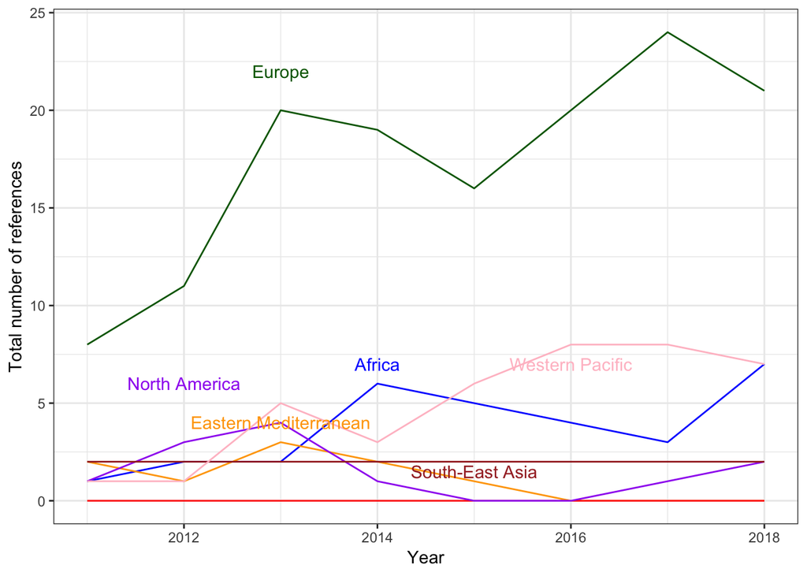

```r
ggplot(proportions_hces_who, aes(x=Year)) +
  geom_line(aes(y=total_speeches_africa), colour="blue", size=.5) +
  geom_line(aes(y=total_speeches_em), colour="orange", size=.5) +
  geom_line(aes(y=total_speeches_europe), colour="darkgreen", size=.5) +
  geom_line(aes(y=total_speeches_latamc), colour="red", size=.5) +
  geom_line(aes(y=total_speeches_na), colour="purple", size=.5) +
  geom_line(aes(y=total_speeches_sea), colour="brown", size=.5) +
  geom_line(aes(y=total_speeches_wp), colour="pink", size=.5) +
  theme_bw() +
  ylab("Total number of references") + xlab("Year") +
  scale_x_continuous(limits=c(2011, 2018), breaks = c(2012,2014,2016,2018)) +
  annotate("text", x = 2014, y = 7, label = "Africa", colour = "blue")+
  annotate("text", x = 2013, y = 4, label = "Eastern Mediterranean", colour = "orange")+
  annotate("text", x = 2013, y = 22, label = "Europe", colour = "darkgreen") +
  #annotate("text", x = 2012, y = 10, label = "Latin Am. & Carribean", colour = "red")+
  annotate("text", x = 2012, y = 6, label = "North America", colour = "purple")+
  annotate("text", x = 2015, y = 1.5, label = "South-East Asia", colour = "brown") +
  annotate("text", x = 2016, y = 7, label = "Western Pacific", colour = "pink")
```

```r
 ggsave("who_countries_percent.pdf")
```

#English Speaking Countries

```r
eng_countries <- c("Australia", "United Kingdom", "United States of America", "Canada", "New Zealand", "South Africa")
eng_texts <- total_counts %>% filter(country %in% eng_countries)

aus_texts <- total_counts %>% filter(country=="Australia") %>% group_by(year) %>% tally(name = "aus_texts")
can_texts <- total_counts %>% filter(country=="Canada") %>% group_by(year) %>% tally(name = "can_texts")
nz_texts <- total_counts %>% filter(country=="New Zealand") %>% group_by(year) %>% tally(name = "nz_texts")
sa_texts <- total_counts %>% filter(country=="South Africa") %>% group_by(year) %>% tally(name = "sa_texts")
uk_texts <- total_counts %>% filter(country=="United Kingdom") %>% group_by(year) %>% tally(name = "uk_texts")
us_texts <- total_counts %>% filter(country=="United States of America") %>% group_by(year) %>% tally(name = "us_texts")

total_texts <- ungc_hces %>% group_by(Year) %>% tally(name = "total_texts")

proportions_eng <- left_join(total_texts, aus_texts, by = c("Year"="year")) %>%
  left_join(., can_texts, by = c("Year"="year")) %>%
  left_join(., nz_texts,  by = c("Year"="year")) %>%
  left_join(., sa_texts,  by = c("Year"="year")) %>%
  left_join(., uk_texts, by = c("Year"="year")) %>%
  left_join(., us_texts,  by = c("Year"="year")) %>%
  replace_na(list(aus_texts=0, can_texts=0, nz_texts=0, sa_texts=0, uk_texts=0, us_texts=0))

proportions_eng$percent_aus <- proportions_eng$aus_texts/proportions_eng$total_texts*100
proportions_eng$percent_can <- proportions_eng$can_texts/proportions_eng$total_texts*100
proportions_eng$percent_nz <- proportions_eng$nz_texts/proportions_eng$total_texts*100
proportions_eng$percent_sa <- proportions_eng$sa_texts/proportions_eng$total_texts*100
proportions_eng$percent_uk <- proportions_eng$uk_texts/proportions_eng$total_texts*100
proportions_eng$percent_us <- proportions_eng$us_texts/proportions_eng$total_texts*100

readr::write_csv(proportions, "proportion_eng_results.csv")
```

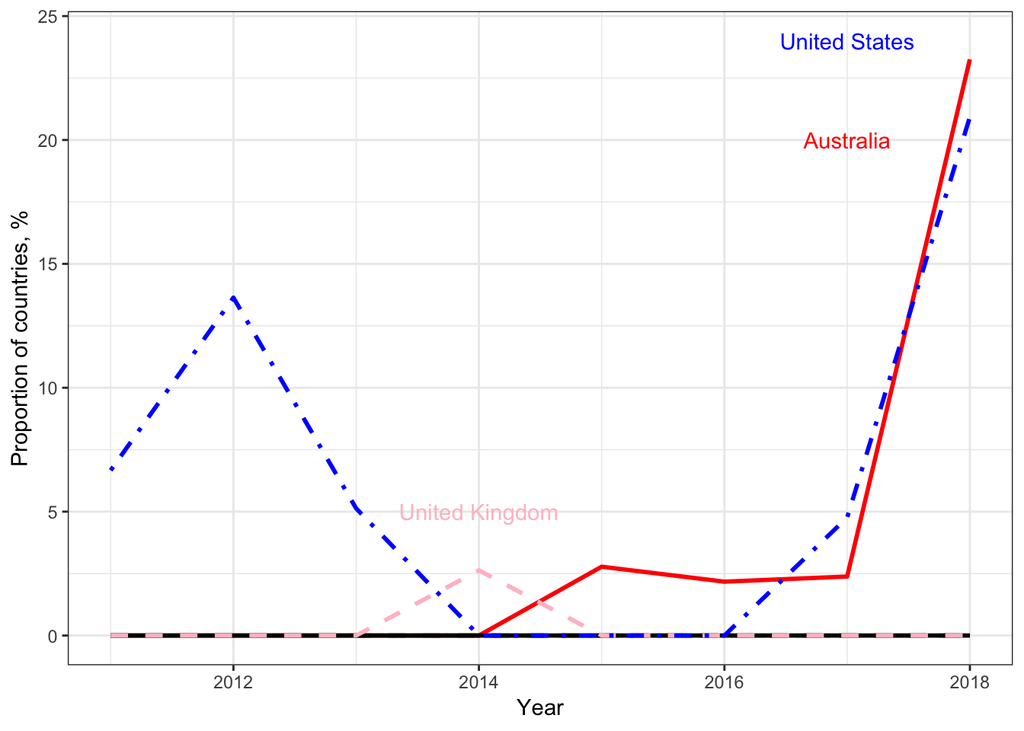

```r
ggplot(proportions_eng, aes(x=Year)) +
  geom_line(aes(y=percent_aus), colour="red", size=1) +
  geom_line(aes(y=percent_can), colour="darkgreen", linetype = "dashed", size=1) +
  geom_line(aes(y=percent_nz), colour="orange", linetype = "dotdash", size=1) +
  geom_line(aes(y=percent_sa), colour="black", size=1) +
  geom_line(aes(y=percent_uk), colour="pink", linetype = "dashed", size=1) +
  geom_line(aes(y=percent_us), colour="blue", linetype = "dotdash", size=1) +
  theme_bw() +
  #ggtitle("Political engagement with the intersection of climate change and health") +
  ylab("Proportion of countries, %") + xlab("Year") +
  scale_x_continuous(limits=c(2011, 2018), breaks = c(2012,2014,2016,2018))+
  annotate("text", x = 2017, y = 20, label = "Australia", colour = "red")+
  annotate("text", x = 2017, y = 24, label = "United States", colour = "blue")+
  annotate("text", x = 2014, y = 5, label = "United Kingdom", colour = "pink")
```

```r
#  ggsave("english_speaking_percent.pdf")
```